# Missing-Data Imputation in NHANES 2017-2018: Controlled Benchmarking and Real-Data Application

Laurin Seelig, Luca Meier, Ravidu Nakandalage

2026-05-04

# 1 Introduction

Missing data are ubiquitous in observational health studies and may strongly influence both predictive performance and inferential validity. In complex survey datasets such as NHANES, missingness can arise from item non-response, laboratory non-completion, or measurement constraints. If not handled rigorously, these mechanisms can produce biased estimates, reduced precision, and potentially misleading substantive conclusions.

This project investigates missing-data handling using two complementary perspectives:

1. **Controlled benchmarking** on complete-case reference data with artificially induced missingness under pre-specified mechanisms (MCAR and MAR) and missingness levels (10%, 20%, 30%), using **8 simulation repetitions** per setting (48 datasets in total).
2. **Real-data application** on NHANES 2017–2018 data, where the true missing values are unknown and conclusions therefore depend on assumptions.

The primary objective is to compare complete-case analysis, single imputation approaches (mean/mode, kNN, missForest), and multiple imputation (MICE) with respect to both **imputation accuracy** and **downstream regression inference** for glycated haemoglobin (HbA1c).

# 2 Theory

## 2.1 Missing-data mechanisms

Let $R$ denote a missingness indicator and $Y$ the data matrix partitioned into observed and missing components.

- **MCAR (Missing Completely At Random):**  
  $P(R \mid Y_{\text{obs}}, Y_{\text{mis}}) = P(R)$.  
  Missingness is independent of both observed and unobserved values. Complete-case analysis is unbiased under MCAR, but this assumption is rarely plausible in health data.
- **MAR (Missing At Random):**  
  $P(R \mid Y_{\text{obs}}, Y_{\text{mis}}) = P(R \mid Y_{\text{obs}})$.  
  Missingness may depend on observed covariates but not on the unobserved values after conditioning. Most modern imputation methods assume MAR.
- **MNAR (Missing Not At Random):**  
  Missingness depends on unobserved values even after conditioning on observed data. MNAR cannot be diagnosed from observed data alone and requires substantive assumptions or sensitivity analyses such as delta-adjustment or pattern-mixture models.

## 2.2 Methods considered

- **Complete-case analysis (CCA):** discards all observations with any missing value. Valid under MCAR (or specific model structures), but reduces effective sample size and can introduce bias under MAR.
- **Mean/mode imputation:** replaces missing values with the variable mean (continuous) or mode (categorical). Simple and fast, but ignores variability in the missing data, attenuates correlations, and underestimates uncertainty in downstream analyses.
- **k-Nearest Neighbours (kNN):** imputes missing values from the $k$ most similar observed records. Captures local data structure but may struggle under higher missingness or sparse overlap ($k = 5$ used here).
- **missForest:** an ensemble-based non-parametric method using random forests to iteratively predict missing values. Handles non-linear relationships and mixed variable types (40 trees used here).
- **Multiple imputation by chained equations (MICE):** generates $m$ complete datasets by iteratively regressing each incomplete variable on all others, then pools estimates using Rubin’s rules. Explicitly propagates imputation uncertainty into standard errors and confidence intervals ($m = 8$, 5 iterations used here).

## 2.3 Evaluation principles

Two complementary performance criteria are used:

1. **Imputation accuracy** at artificially masked cells:
   - Normalised RMSE (NRMSE = RMSE / SD of observed variable) for continuous variables; values below 1.0 indicate the method outperforms naive mean imputation.
   - Proportion of falsely classified values (PFC) for categorical variables.
2. **Inferential performance** in the downstream model:
   $$\text{HbA1c} \sim \text{age} + \text{sex} +
   \text{BMI} + \text{systolic\_bp} + \text{smoking\_status} +
   \text{income\_ratio}$$
   summarised by coefficient bias (estimate minus reference), empirical standard deviation, model-based standard errors, 95% confidence-interval coverage, and interval width.

# 3 Data

The analysis is based on NHANES 2017–2018 and prepared using scripted extraction and cleaning from CDC XPT files. The final analysis dataset contains $n = 2{,}000$ adult participants (age $\geq$ 20 years) and seven variables relevant to metabolic health.

```r
nhanes_analysis     <- safe_read_csv("data/nhanes_analysis.csv")
missing_var_summary <- safe_read_csv("outputs/missingness_variable_summary.csv")
missing_desc        <- safe_read_csv("outputs/missingness_descriptive_table.csv")
```

```r
if (!is.null(nhanes_analysis)) {
  data_overview <- tibble::tibble(
    Metric = c("Number of observations", "Number of variables"),
    Value  = c(nrow(nhanes_analysis), ncol(nhanes_analysis))
  )
  knitr::kable(data_overview, caption = "Table 1: Overview of the prepared NHANES analysis dataset.")
}
```

Table 1: Overview of the prepared NHANES analysis dataset.

| Metric | Value |
| --- | --- |
| Number of observations | 2000 |
| Number of variables | 7 |

```r
if (!is.null(missing_var_summary)) {
  knitr::kable(
    missing_var_summary,
    col.names = c("Variable", "N missing", "N total", "Missing (%)"),
    caption   = "Table 2: Variable-level missingness in the prepared NHANES analysis dataset."
  )
}
```

Table 2: Variable-level missingness in the prepared NHANES analysis dataset.

| Variable | N missing | N total | Missing (%) |
| --- | --- | --- | --- |
| income_ratio | 387 | 2000 | 19.35 |
| systolic_bp | 210 | 2000 | 10.50 |
| hba1c | 192 | 2000 | 9.60 |
| bmi | 141 | 2000 | 7.05 |
| age | 0 | 2000 | 0.00 |
| sex | 0 | 2000 | 0.00 |
| smoking_status | 0 | 2000 | 0.00 |

The income-to-poverty ratio has the highest proportion of missing values (19.4%), followed by systolic blood pressure (10.5%), HbA1c (9.6%), and BMI (7.1%). Age, sex, and smoking status are fully observed.

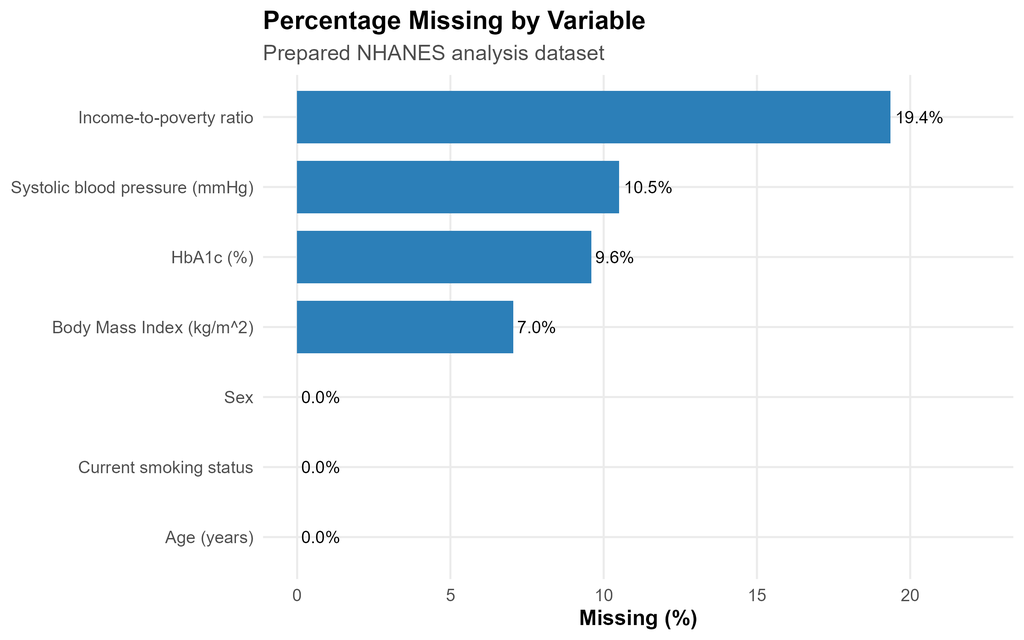

Figure 1: Percentage of missing values by variable in the prepared NHANES analysis dataset.

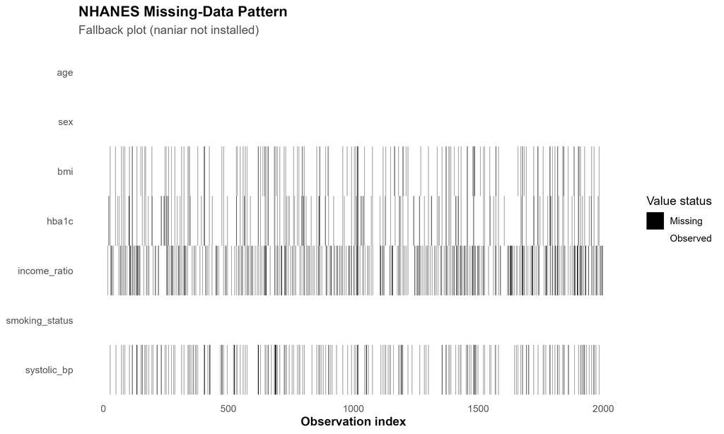

# 4 Methods

## 4.1 Controlled benchmarking design

A complete-case reference subset ($n = 1{,}000$) was used to induce artificial missingness in predictors at 10%, 20%, and 30% under two mechanisms:

- **MCAR:** random masking, independent of all data.
- **MAR:** logistic masking probabilities dependent on observed age, sex, and BMI.

For each of the 6 mechanism–level combinations, **8 repetitions** were generated, yielding **48 simulated datasets** in total. Masked-cell indices and true values were retained for accuracy evaluation.

```r
sim_manifest <- safe_read_csv("sim_data/simulation_manifest.csv")
if (!is.null(sim_manifest)) {
  sim_overview <- sim_manifest %>%
    group_by(mechanism, missing_rate) %>%
    summarise(
      n_repetitions     = n(),
      mean_masked_cells = mean(n_masked_cells),
      .groups = "drop"
    )
  knitr::kable(
    sim_overview,
    col.names = c("Mechanism", "Missing rate", "Repetitions", "Mean masked cells"),
    caption   = "Table 3: Simulation design summary by mechanism and missingness level."
  )
}
```

Table 3: Simulation design summary by mechanism and missingness level.

| Mechanism | Missing rate | Repetitions | Mean masked cells |
| --- | --- | --- | --- |
| MAR | 0.1 | 8 | 600 |
| MAR | 0.2 | 8 | 1200 |
| MAR | 0.3 | 8 | 1800 |
| MCAR | 0.1 | 8 | 600 |
| MCAR | 0.2 | 8 | 1200 |
| MCAR | 0.3 | 8 | 1800 |

## 4.2 Imputation methods

Five approaches were applied to each simulated dataset:

| Method | Type | Key parameters |
| --- | --- | --- |
| Complete-case analysis | — | Listwise deletion |
| Mean/mode imputation | Single | Mean (continuous), mode (categorical) |
| kNN | Single | $k = 5$ |
| missForest | Single | 40 trees |
| MICE | Multiple | $m = 8$, 5 iterations, PMM / logreg / polyreg |

For MICE, variable-type-appropriate methods were used: predictive mean matching (`pmm`) for continuous variables, logistic regression (`logreg`) for binary factors, and polytomous regression (`polyreg`) for unordered factors. Final inference was obtained by pooling via Rubin’s rules.

## 4.3 Downstream inferential model

After imputation, a linear model for HbA1c was fit in each repetition. For MICE, results were pooled using `with()` and `pool()` from the `mice` package. The reference coefficients were estimated from the complete-case reference subset (before missingness was introduced).

## 4.4 Real-data application

For the observed NHANES data, the same model was applied to (i) complete cases only and (ii) a MICE analysis (20 imputations, 10 iterations), yielding pooled coefficients and confidence intervals. This analysis is interpretive, because the true missing values are unknown.